# Notebook 5.1 - Continuous Facility Location

```python
import numpy as np
import matplotlib
import matplotlib.pyplot as plt
import seaborn as sns; sns.set()
from sklearn.datasets import make_blobs

%matplotlib inline

plot_size   = 14
plot_width  = 5
plot_height = 5

params = {'legend.fontsize': 'large',
          'figure.figsize': (plot_width,plot_height),
          'axes.labelsize': plot_size,
          'axes.titlesize': plot_size,
          'xtick.labelsize': plot_size*0.75,
          'ytick.labelsize': plot_size*0.75,
          'axes.titlepad': 25}
plt.rcParams.update(params)
```

As before, we are importing the packages tht we are going to use, and prepare the properties of the plots.

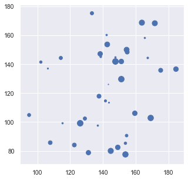

```python
num_customers = 40

center_box = (100, 200) # defines the box that cluster centres are allowed to be in

coord, clust_true = make_blobs(n_samples=num_customers,
                               centers=2,
                               cluster_std=20,
                               center_box=center_box,
                               random_state = 2)

weights = list(np.random.uniform(size=len(coord)))

for i in range(len(coord)):
    plt.scatter(coord[i, 0], coord[i, 1], s=weights[i]*100, c='b');
```

We will use the `make_blobs` command again to generate a set of customers. What we do differently here, however, is to to define a `centre_box` vector, that forces the generator to position points around a different point (the default value is 0,0).

```python
import csv

with open("flp_coords.csv","w+") as my_csv:
    csvWriter = csv.writer(my_csv,delimiter=',')
    csvWriter.writerows(coord)
```

Using the `csv` package, we are saving the coordinates to a csv file (`flp_coords.csv`) in the same directory.

```python
from cvxpy import Minimize, Problem, CVXOPT
from cvxpy.atoms.affine.sum import sum as csum
from cvxpy.expressions.variable import Variable
from cvxpy.atoms.norm import norm
from cvxpy.atoms.elementwise.sqrt import sqrt
from cvxpy.atoms.elementwise.square import square
```

We are using the `cvxpy` to solve the continuous facility location problem. Unfortunately, we cannot use the default solver provided by `PuLP` as they are not capable of handling the non-linearities that are present in the formulation.

As `cvxpy` is fairly complex and is not used elsewhere in this module, we are providing this formulation for your information only, and without comments.

You might, however, recognise some similarities in syntax between `cvxpy` and `PuLP` models.

```python
x = list(coord[:,0])
y = list(coord[:,1])

K = len(x)

xvar = Variable()
yvar = Variable()
```

```python
objective_function = Minimize(csum([weights[k]*(square(xvar-x[k])+square(yvar-y[k])) for k in range(K)]))
```

```python
problem = Problem(objective_function)
problem.solve(solver=CVXOPT)
```

```
23162.72737073052
```

```python
print('x: ',xvar.value)
print('y: ', yvar.value)
```

```
x:  147.0744578552203
y:  122.3586425058362
```

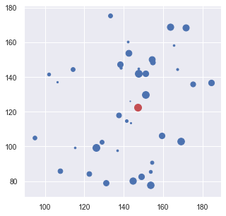

```python
for i in range(len(coord)):
    plt.scatter(coord[i, 0], coord[i, 1], s=weights[i]*100,c='b');
plt.scatter(xvar.value, yvar.value, s=100,c='r')
```